# Ecoforecast Africa

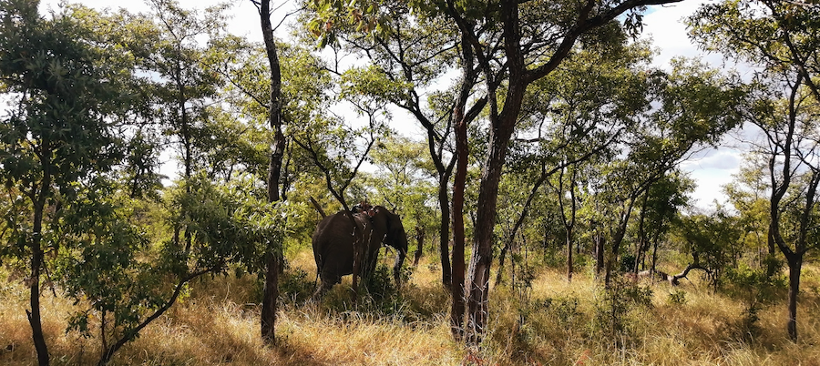

Jasper Slingsby

Centre for Statistics in Ecology, the Environment and Conservation, Department of Biological Sciences, University of Cape Town

South African Environmental Observation Network, Fynbos Node

## Why an EFI for Africa?

Most data products that inform global policy are developed in the Global North, but these are erroneous in places, largely due to lack of local knowledge…

[interactive chart not shown]

Being “stakeholders” is not good enough. We need Africans holding the reigns.

www.globalforestwatch.org

## Everyone else is getting one?

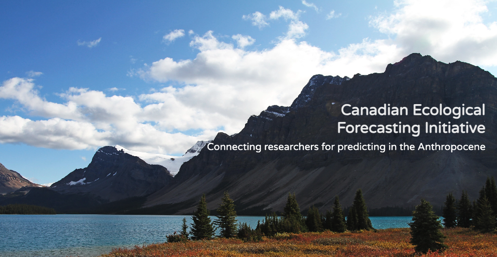

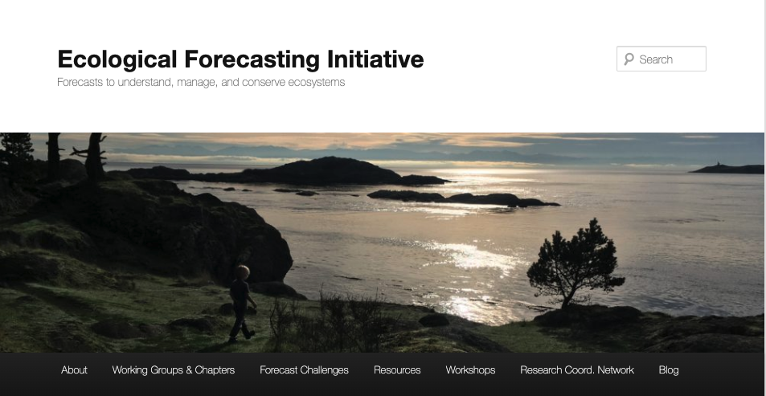

[figure not shown]

[figure not shown]

We don’t want Africa left behind… again…

## Africa contribute significant data…

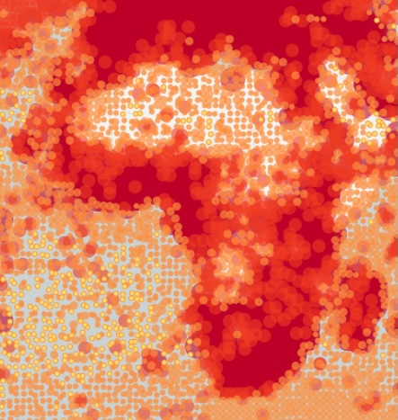

But either the data are not being sufficiently used, or when they are, we tend to collaborate with folks outside Africa to analyse it…

Collaboration within Africa is limited, and often dominated by Global North partners.

This often contributes to global data products or theory, but less often to local needs.

## So what are we doing?

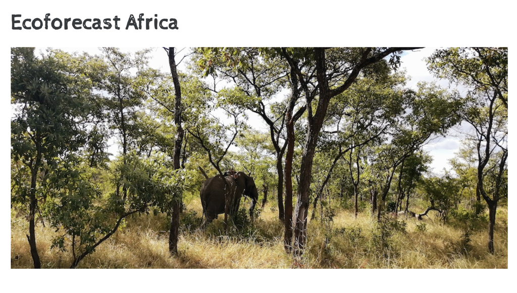

Started a website - https://ecoforecast.africa

- Building a community of practice to develop ecoforecasting capacity in Africa
- Web form for sign-ups and advertised through various channels
- Held our first meeting to discuss and plan the way forward in May
  - Early days, but we have a lot of interest and enthusiasm

## So what are we doing?

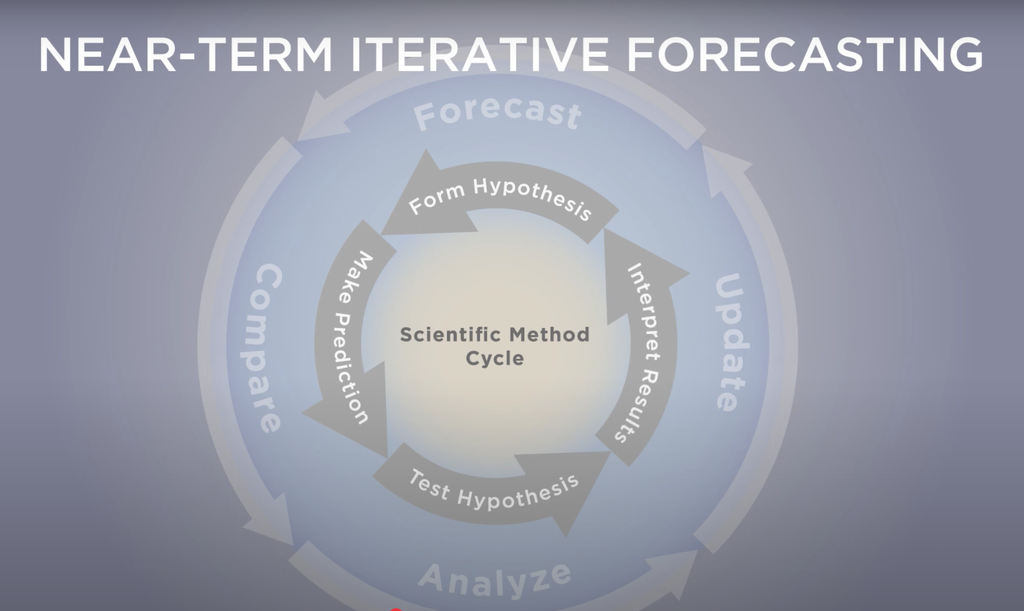

- Running an in-person training workshop
  - 21-25 July 2025
  - Cape Town, South Africa
- Instruction led by Prof Mike Dietze, Boston University, USA and EFI founder
  - Supported by UCT-SEEC and SAEON

## Interest in Ecoforecast Africa so far?

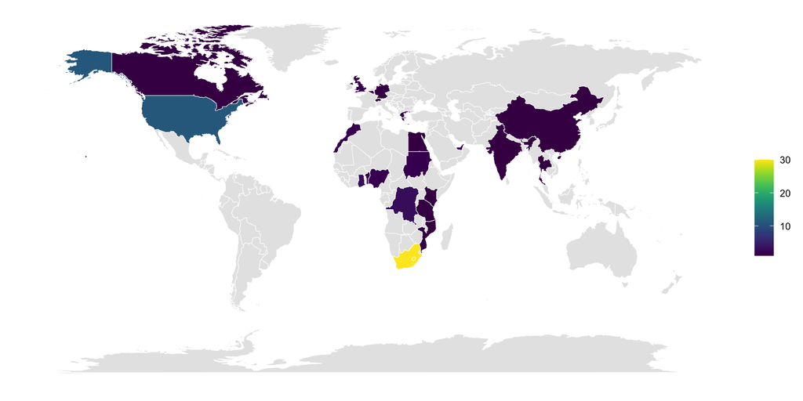

Africa 49 (13 countries) | North America 12 | Europe 6 | Asia 4 | Many from or work in Africa

## Interest in Ecoforecast Africa so far?

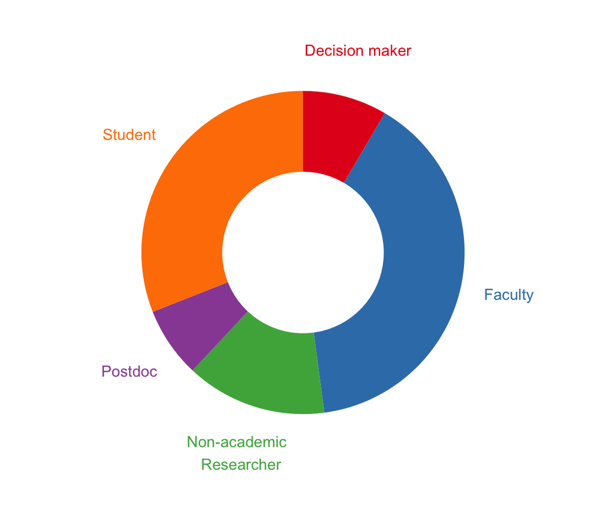

## Interest in Ecoforecast Africa so far?

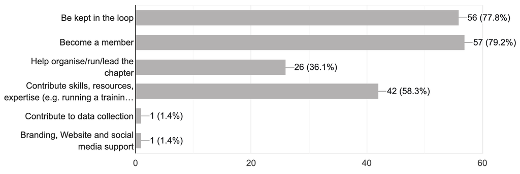

Great willingness to contribute skills!!! Especially from members of other EFIs

Much interest in research collaboration too!

## Please sign up!

[figure not shown]

https://ecoforecast.africa/join

## Where to from here?

- What model to adopt re governance?
  - Steering committee and working groups?
- Expanding across Africa
  - Talks/Sessions at conferences?
  - Online seminars?
  - Running courses?
- Student group?
  - To help build capacity and provide a platform for students to learn and contribute.
- Funding?
  - EU-linked?
- SEEC and Ecological Forecasting?

## Please sign up!

[figure not shown]

https://ecoforecast.africa/join

# Thanks!!!

https://ecoforecast.africa